# Risk Factor Analysis

## Outcome Variable

**Outcome Variable:** wasted

## Predictor Variables

**Intervention Variable:** earlybf

**Adjustment Set:**

- arm
- sex
- W_mage
- meducyrs
- feducyrs
- hhwealth_quart
- hfoodsec
- W_mhtcm
- vagbrth
- W_gagebrth
- W_birthwt
- W_birthlen
- W_nrooms
- W_nchldlt5
- brthmon
- W_parity
- impfloor
- impsan
- safeh20
- delta_W_mage
- delta_meducyrs
- delta_feducyrs
- delta_hhwealth_quart
- delta_hfoodsec
- delta_W_mhtcm
- delta_vagbrth
- delta_W_gagebrth
- delta_W_birthwt
- delta_W_birthlen
- delta_W_nrooms
- delta_W_nchldlt5
- delta_brthmon
- delta_W_parity
- delta_impfloor
- delta_impsan
- delta_safeh20

## Stratifying Variables

The analysis was stratified on these variable(s):

- agecat
- studyid
- country

## Data Summary

| agecat | studyid | country | earlybf | wasted | n_cell | n |
| --- | --- | --- | --- | --- | --- | --- |
| Birth | ki0047075b-MAL-ED | BANGLADESH | 0 | 0 | 70 | 240 |
| Birth | ki0047075b-MAL-ED | BANGLADESH | 0 | 1 | 18 | 240 |
| Birth | ki0047075b-MAL-ED | BANGLADESH | 1 | 0 | 130 | 240 |
| Birth | ki0047075b-MAL-ED | BANGLADESH | 1 | 1 | 22 | 240 |
| Birth | ki0047075b-MAL-ED | BRAZIL | 0 | 0 | 100 | 183 |
| Birth | ki0047075b-MAL-ED | BRAZIL | 0 | 1 | 4 | 183 |
| Birth | ki0047075b-MAL-ED | BRAZIL | 1 | 0 | 77 | 183 |
| Birth | ki0047075b-MAL-ED | BRAZIL | 1 | 1 | 2 | 183 |
| Birth | ki0047075b-MAL-ED | INDIA | 0 | 0 | 65 | 202 |
| Birth | ki0047075b-MAL-ED | INDIA | 0 | 1 | 14 | 202 |
| Birth | ki0047075b-MAL-ED | INDIA | 1 | 0 | 104 | 202 |
| Birth | ki0047075b-MAL-ED | INDIA | 1 | 1 | 19 | 202 |
| Birth | ki0047075b-MAL-ED | NEPAL | 0 | 0 | 83 | 168 |
| Birth | ki0047075b-MAL-ED | NEPAL | 0 | 1 | 8 | 168 |
| Birth | ki0047075b-MAL-ED | NEPAL | 1 | 0 | 65 | 168 |
| Birth | ki0047075b-MAL-ED | NEPAL | 1 | 1 | 12 | 168 |
| Birth | ki0047075b-MAL-ED | PERU | 0 | 0 | 66 | 279 |
| Birth | ki0047075b-MAL-ED | PERU | 0 | 1 | 2 | 279 |
| Birth | ki0047075b-MAL-ED | PERU | 1 | 0 | 207 | 279 |
| Birth | ki0047075b-MAL-ED | PERU | 1 | 1 | 4 | 279 |
| Birth | ki0047075b-MAL-ED | SOUTH AFRICA | 0 | 0 | 81 | 245 |
| Birth | ki0047075b-MAL-ED | SOUTH AFRICA | 0 | 1 | 10 | 245 |
| Birth | ki0047075b-MAL-ED | SOUTH AFRICA | 1 | 0 | 148 | 245 |
| Birth | ki0047075b-MAL-ED | SOUTH AFRICA | 1 | 1 | 6 | 245 |
| Birth | ki0047075b-MAL-ED | TANZANIA, UNITED REPUBLIC OF | 0 | 0 | 10 | 118 |
| Birth | ki0047075b-MAL-ED | TANZANIA, UNITED REPUBLIC OF | 0 | 1 | 0 | 118 |
| Birth | ki0047075b-MAL-ED | TANZANIA, UNITED REPUBLIC OF | 1 | 0 | 106 | 118 |
| Birth | ki0047075b-MAL-ED | TANZANIA, UNITED REPUBLIC OF | 1 | 1 | 2 | 118 |
| Birth | ki1000109-EE | PAKISTAN | 0 | 0 | 0 | 2 |
| Birth | ki1000109-EE | PAKISTAN | 0 | 1 | 0 | 2 |

[output cut: 126 more lines]

The following strata were considered:

- agecat: 24 months, studyid: ki0047075b-MAL-ED, country: BANGLADESH
- agecat: 24 months, studyid: ki0047075b-MAL-ED, country: BRAZIL
- agecat: 24 months, studyid: ki0047075b-MAL-ED, country: INDIA
- agecat: 24 months, studyid: ki0047075b-MAL-ED, country: NEPAL
- agecat: 24 months, studyid: ki0047075b-MAL-ED, country: PERU
- agecat: 24 months, studyid: ki0047075b-MAL-ED, country: SOUTH AFRICA
- agecat: 24 months, studyid: ki0047075b-MAL-ED, country: TANZANIA, UNITED REPUBLIC OF
- agecat: 24 months, studyid: ki1017093c-NIH-Crypto, country: BANGLADESH
- agecat: 24 months, studyid: ki1113344-GMS-Nepal, country: NEPAL
- agecat: 24 months, studyid: ki1126311-ZVITAMBO, country: ZIMBABWE
- agecat: 24 months, studyid: kiGH5241-JiVitA-3, country: BANGLADESH
- agecat: 24 months, studyid: kiGH5241-JiVitA-4, country: BANGLADESH
- agecat: 6 months, studyid: ki0047075b-MAL-ED, country: BANGLADESH
- agecat: 6 months, studyid: ki0047075b-MAL-ED, country: BRAZIL
- agecat: 6 months, studyid: ki0047075b-MAL-ED, country: INDIA
- agecat: 6 months, studyid: ki0047075b-MAL-ED, country: NEPAL
- agecat: 6 months, studyid: ki0047075b-MAL-ED, country: PERU
- agecat: 6 months, studyid: ki0047075b-MAL-ED, country: SOUTH AFRICA
- agecat: 6 months, studyid: ki0047075b-MAL-ED, country: TANZANIA, UNITED REPUBLIC OF
- agecat: 6 months, studyid: ki1000109-EE, country: PAKISTAN
- agecat: 6 months, studyid: ki1000304b-SAS-CompFeed, country: INDIA
- agecat: 6 months, studyid: ki1017093c-NIH-Crypto, country: BANGLADESH
- agecat: 6 months, studyid: ki1113344-GMS-Nepal, country: NEPAL
- agecat: 6 months, studyid: ki1126311-ZVITAMBO, country: ZIMBABWE
- agecat: 6 months, studyid: kiGH5241-JiVitA-3, country: BANGLADESH
- agecat: 6 months, studyid: kiGH5241-JiVitA-4, country: BANGLADESH
- agecat: Birth, studyid: ki0047075b-MAL-ED, country: BANGLADESH
- agecat: Birth, studyid: ki0047075b-MAL-ED, country: BRAZIL
- agecat: Birth, studyid: ki0047075b-MAL-ED, country: INDIA
- agecat: Birth, studyid: ki0047075b-MAL-ED, country: NEPAL
- agecat: Birth, studyid: ki0047075b-MAL-ED, country: PERU
- agecat: Birth, studyid: ki0047075b-MAL-ED, country: SOUTH AFRICA
- agecat: Birth, studyid: ki0047075b-MAL-ED, country: TANZANIA, UNITED REPUBLIC OF
- agecat: Birth, studyid: ki1000109-EE, country: PAKISTAN
- agecat: Birth, studyid: ki1000304b-SAS-CompFeed, country: INDIA
- agecat: Birth, studyid: ki1017093c-NIH-Crypto, country: BANGLADESH
- agecat: Birth, studyid: ki1126311-ZVITAMBO, country: ZIMBABWE
- agecat: Birth, studyid: kiGH5241-JiVitA-3, country: BANGLADESH
- agecat: Birth, studyid: kiGH5241-JiVitA-4, country: BANGLADESH

### Dropped Strata

Some strata were dropped due to rare outcomes:

- agecat: Birth, studyid: ki0047075b-MAL-ED, country: BRAZIL
- agecat: Birth, studyid: ki0047075b-MAL-ED, country: PERU
- agecat: Birth, studyid: ki0047075b-MAL-ED, country: TANZANIA, UNITED REPUBLIC OF
- agecat: Birth, studyid: ki1000109-EE, country: PAKISTAN
- agecat: Birth, studyid: ki1000304b-SAS-CompFeed, country: INDIA
- agecat: Birth, studyid: ki1017093c-NIH-Crypto, country: BANGLADESH
- agecat: 6 months, studyid: ki0047075b-MAL-ED, country: BANGLADESH
- agecat: 6 months, studyid: ki0047075b-MAL-ED, country: BRAZIL
- agecat: 6 months, studyid: ki0047075b-MAL-ED, country: NEPAL
- agecat: 6 months, studyid: ki0047075b-MAL-ED, country: PERU
- agecat: 6 months, studyid: ki0047075b-MAL-ED, country: SOUTH AFRICA
- agecat: 6 months, studyid: ki0047075b-MAL-ED, country: TANZANIA, UNITED REPUBLIC OF
- agecat: 6 months, studyid: ki1017093c-NIH-Crypto, country: BANGLADESH
- agecat: 24 months, studyid: ki0047075b-MAL-ED, country: BRAZIL
- agecat: 24 months, studyid: ki0047075b-MAL-ED, country: NEPAL
- agecat: 24 months, studyid: ki0047075b-MAL-ED, country: PERU
- agecat: 24 months, studyid: ki0047075b-MAL-ED, country: SOUTH AFRICA
- agecat: 24 months, studyid: ki0047075b-MAL-ED, country: TANZANIA, UNITED REPUBLIC OF
- agecat: 24 months, studyid: ki1017093c-NIH-Crypto, country: BANGLADESH
- agecat: 24 months, studyid: kiGH5241-JiVitA-3, country: BANGLADESH

## Methods Detail

We’re interested in the causal parameters $E[Y_a]$ for all values of $a \in \mathcal{A}$. These parameters represent the mean outcome if, possibly contrary to fact, we intervened to set all units to have $A=a$. Under the randomization and positivity assumptions, these are identified by the statistical parameters $\psi_a=E_W[E_{Y|A,W}(Y|A=a,W)]$. In addition, we’re interested in the mean of $Y$, $E[Y]$ under no intervention (the observed mean). We will estimate these parameters by using SuperLearner to fit the relevant likelihood factors – $E_{Y|A,W}(Y|A=a,W)$ and $p(A=a|W)$, and then updating our likelihood fit using a joint TMLE.

For unadjusted analyses ($W=\{\}$), initial likelihoods were estimated using Lrnr_glm to estimate the simple $E(Y|A)$ and Lrnr_mean to estimate $p(A)$. For adjusted analyses, a small library containing Lrnr_glmnet, Lrnr_xgboost, and Lrnr_mean was used.

Having estimated these parameters, we will then use the delta method to estimate relative risks and attributable risks relative to a prespecified baseline level of $A$.

# Results Detail

## Results Plots

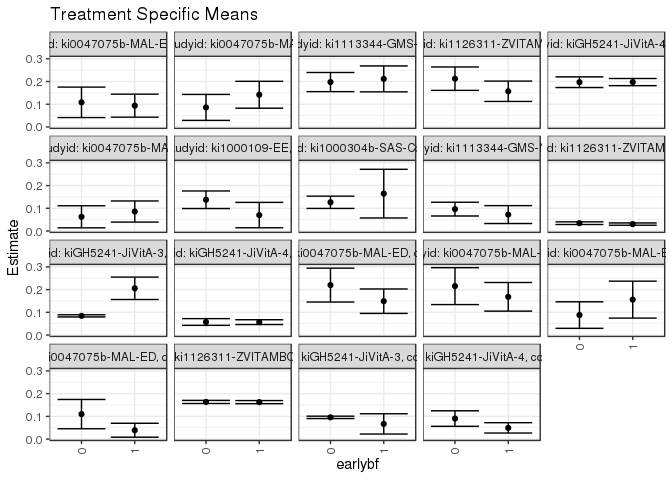

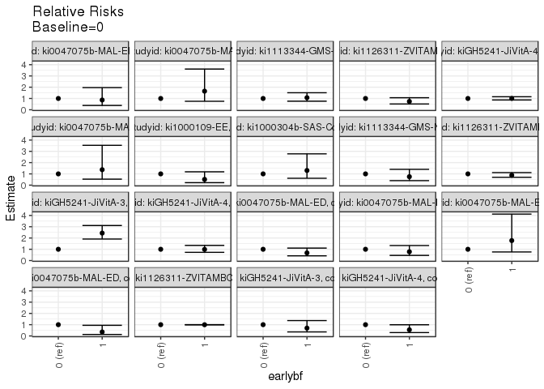

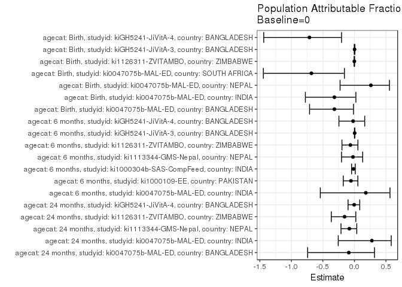

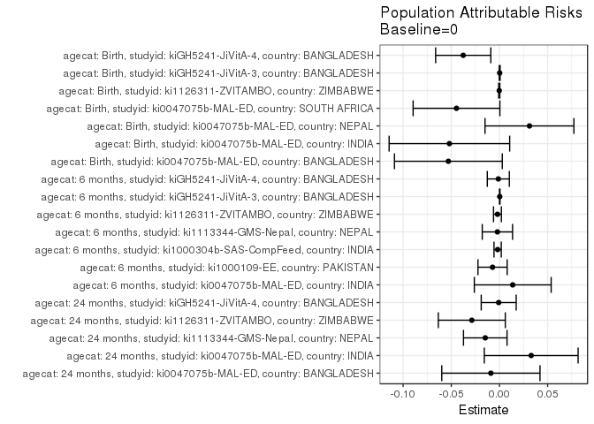

## Results Table

### Parameter: TSM

| agecat | studyid | country | intervention_level | baseline_level | estimate | ci_lower | ci_upper |
| --- | --- | --- | --- | --- | --- | --- | --- |
| Birth | ki0047075b-MAL-ED | BANGLADESH | 0 | NA | 0.2196854 | 0.1451833 | 0.2941876 |
| Birth | ki0047075b-MAL-ED | BANGLADESH | 1 | NA | 0.1489479 | 0.0952395 | 0.2026562 |
| Birth | ki0047075b-MAL-ED | INDIA | 0 | NA | 0.2153192 | 0.1341344 | 0.2965040 |
| Birth | ki0047075b-MAL-ED | INDIA | 1 | NA | 0.1682221 | 0.1051902 | 0.2312540 |
| Birth | ki0047075b-MAL-ED | NEPAL | 0 | NA | 0.0879121 | 0.0295587 | 0.1462655 |
| Birth | ki0047075b-MAL-ED | NEPAL | 1 | NA | 0.1558442 | 0.0745881 | 0.2371002 |
| Birth | ki0047075b-MAL-ED | SOUTH AFRICA | 0 | NA | 0.1098901 | 0.0455004 | 0.1742798 |
| Birth | ki0047075b-MAL-ED | SOUTH AFRICA | 1 | NA | 0.0389610 | 0.0083371 | 0.0695850 |
| Birth | ki1126311-ZVITAMBO | ZIMBABWE | 0 | NA | 0.1634291 | 0.1566467 | 0.1702114 |
| Birth | ki1126311-ZVITAMBO | ZIMBABWE | 1 | NA | 0.1626394 | 0.1558900 | 0.1693888 |
| Birth | kiGH5241-JiVitA-3 | BANGLADESH | 0 | NA | 0.0957084 | 0.0904754 | 0.1009413 |
| Birth | kiGH5241-JiVitA-3 | BANGLADESH | 1 | NA | 0.0668186 | 0.0223052 | 0.1113320 |
| Birth | kiGH5241-JiVitA-4 | BANGLADESH | 0 | NA | 0.0903165 | 0.0561464 | 0.1244866 |
| Birth | kiGH5241-JiVitA-4 | BANGLADESH | 1 | NA | 0.0494072 | 0.0266783 | 0.0721360 |
| 6 months | ki0047075b-MAL-ED | INDIA | 0 | NA | 0.0625000 | 0.0139756 | 0.1110244 |
| 6 months | ki0047075b-MAL-ED | INDIA | 1 | NA | 0.0857143 | 0.0392442 | 0.1321844 |
| 6 months | ki1000109-EE | PAKISTAN | 0 | NA | 0.1374811 | 0.0988490 | 0.1761132 |
| 6 months | ki1000109-EE | PAKISTAN | 1 | NA | 0.0700854 | 0.0143380 | 0.1258327 |
| 6 months | ki1000304b-SAS-CompFeed | INDIA | 0 | NA | 0.1263309 | 0.0994047 | 0.1532572 |
| 6 months | ki1000304b-SAS-CompFeed | INDIA | 1 | NA | 0.1644577 | 0.0574247 | 0.2714906 |
| 6 months | ki1113344-GMS-Nepal | NEPAL | 0 | NA | 0.0962602 | 0.0659928 | 0.1265276 |
| 6 months | ki1113344-GMS-Nepal | NEPAL | 1 | NA | 0.0722186 | 0.0328396 | 0.1115977 |
| 6 months | ki1126311-ZVITAMBO | ZIMBABWE | 0 | NA | 0.0344978 | 0.0287102 | 0.0402853 |
| 6 months | ki1126311-ZVITAMBO | ZIMBABWE | 1 | NA | 0.0304126 | 0.0253101 | 0.0355152 |
| 6 months | kiGH5241-JiVitA-3 | BANGLADESH | 0 | NA | 0.0844508 | 0.0796582 | 0.0892435 |
| 6 months | kiGH5241-JiVitA-3 | BANGLADESH | 1 | NA | 0.2057558 | 0.1564694 | 0.2550422 |
| 6 months | kiGH5241-JiVitA-4 | BANGLADESH | 0 | NA | 0.0574399 | 0.0427112 | 0.0721686 |
| 6 months | kiGH5241-JiVitA-4 | BANGLADESH | 1 | NA | 0.0568310 | 0.0462713 | 0.0673907 |
| 24 months | ki0047075b-MAL-ED | BANGLADESH | 0 | NA | 0.1084337 | 0.0413836 | 0.1754839 |
| 24 months | ki0047075b-MAL-ED | BANGLADESH | 1 | NA | 0.0937500 | 0.0431344 | 0.1443656 |
| 24 months | ki0047075b-MAL-ED | INDIA | 0 | NA | 0.0860215 | 0.0289083 | 0.1431348 |
| 24 months | ki0047075b-MAL-ED | INDIA | 1 | NA | 0.1417910 | 0.0825974 | 0.2009847 |
| 24 months | ki1113344-GMS-Nepal | NEPAL | 0 | NA | 0.1975545 | 0.1555383 | 0.2395707 |
| 24 months | ki1113344-GMS-Nepal | NEPAL | 1 | NA | 0.2115263 | 0.1545570 | 0.2684957 |
| 24 months | ki1126311-ZVITAMBO | ZIMBABWE | 0 | NA | 0.2124836 | 0.1610279 | 0.2639393 |
| 24 months | ki1126311-ZVITAMBO | ZIMBABWE | 1 | NA | 0.1570657 | 0.1122877 | 0.2018436 |
| 24 months | kiGH5241-JiVitA-4 | BANGLADESH | 0 | NA | 0.1969822 | 0.1735114 | 0.2204531 |
| 24 months | kiGH5241-JiVitA-4 | BANGLADESH | 1 | NA | 0.1974306 | 0.1816642 | 0.2131970 |

### Parameter: E(Y)

| agecat | studyid | country | intervention_level | baseline_level | estimate | ci_lower | ci_upper |
| --- | --- | --- | --- | --- | --- | --- | --- |
| Birth | ki0047075b-MAL-ED | BANGLADESH | NA | NA | 0.1666667 | 0.1194187 | 0.2139146 |
| Birth | ki0047075b-MAL-ED | INDIA | NA | NA | 0.1633663 | 0.1122571 | 0.2144755 |
| Birth | ki0047075b-MAL-ED | NEPAL | NA | NA | 0.1190476 | 0.0699312 | 0.1681640 |
| Birth | ki0047075b-MAL-ED | SOUTH AFRICA | NA | NA | 0.0653061 | 0.0343059 | 0.0963063 |
| Birth | ki1126311-ZVITAMBO | ZIMBABWE | NA | NA | 0.1632068 | 0.1564561 | 0.1699575 |
| Birth | kiGH5241-JiVitA-3 | BANGLADESH | NA | NA | 0.0959228 | 0.0907196 | 0.1011260 |
| Birth | kiGH5241-JiVitA-4 | BANGLADESH | NA | NA | 0.0527086 | 0.0336587 | 0.0717585 |
| 6 months | ki0047075b-MAL-ED | INDIA | NA | NA | 0.0762712 | 0.0423347 | 0.1102077 |
| 6 months | ki1000109-EE | PAKISTAN | NA | NA | 0.1303191 | 0.0962457 | 0.1643926 |
| 6 months | ki1000304b-SAS-CompFeed | INDIA | NA | NA | 0.1244378 | 0.0992652 | 0.1496104 |
| 6 months | ki1113344-GMS-Nepal | NEPAL | NA | NA | 0.0941176 | 0.0687511 | 0.1194842 |
| 6 months | ki1126311-ZVITAMBO | ZIMBABWE | NA | NA | 0.0324295 | 0.0283765 | 0.0364824 |
| 6 months | kiGH5241-JiVitA-3 | BANGLADESH | NA | NA | 0.0847478 | 0.0799486 | 0.0895469 |
| 6 months | kiGH5241-JiVitA-4 | BANGLADESH | NA | NA | 0.0562606 | 0.0473198 | 0.0652014 |
| 24 months | ki0047075b-MAL-ED | BANGLADESH | NA | NA | 0.0995261 | 0.0590366 | 0.1400156 |
| 24 months | ki0047075b-MAL-ED | INDIA | NA | NA | 0.1189427 | 0.0767376 | 0.1611478 |
| 24 months | ki1113344-GMS-Nepal | NEPAL | NA | NA | 0.1828194 | 0.1472260 | 0.2184128 |
| 24 months | ki1126311-ZVITAMBO | ZIMBABWE | NA | NA | 0.1837838 | 0.1442661 | 0.2233014 |
| 24 months | kiGH5241-JiVitA-4 | BANGLADESH | NA | NA | 0.1961929 | 0.1827435 | 0.2096424 |

### Parameter: RR

| agecat | studyid | country | intervention_level | baseline_level | estimate | ci_lower | ci_upper |
| --- | --- | --- | --- | --- | --- | --- | --- |
| Birth | ki0047075b-MAL-ED | BANGLADESH | 0 | 0 | 1.0000000 | 1.0000000 | 1.0000000 |
| Birth | ki0047075b-MAL-ED | BANGLADESH | 1 | 0 | 0.6780052 | 0.4159417 | 1.1051814 |
| Birth | ki0047075b-MAL-ED | INDIA | 0 | 0 | 1.0000000 | 1.0000000 | 1.0000000 |
| Birth | ki0047075b-MAL-ED | INDIA | 1 | 0 | 0.7812684 | 0.4584171 | 1.3314952 |
| Birth | ki0047075b-MAL-ED | NEPAL | 0 | 0 | 1.0000000 | 1.0000000 | 1.0000000 |
| Birth | ki0047075b-MAL-ED | NEPAL | 1 | 0 | 1.7727273 | 0.7622022 | 4.1230032 |
| Birth | ki0047075b-MAL-ED | SOUTH AFRICA | 0 | 0 | 1.0000000 | 1.0000000 | 1.0000000 |
| Birth | ki0047075b-MAL-ED | SOUTH AFRICA | 1 | 0 | 0.3545455 | 0.1330137 | 0.9450341 |
| Birth | ki1126311-ZVITAMBO | ZIMBABWE | 0 | 0 | 1.0000000 | 1.0000000 | 1.0000000 |
| Birth | ki1126311-ZVITAMBO | ZIMBABWE | 1 | 0 | 0.9951684 | 0.9875726 | 1.0028225 |
| Birth | kiGH5241-JiVitA-3 | BANGLADESH | 0 | 0 | 1.0000000 | 1.0000000 | 1.0000000 |
| Birth | kiGH5241-JiVitA-3 | BANGLADESH | 1 | 0 | 0.6981477 | 0.3569825 | 1.3653618 |
| Birth | kiGH5241-JiVitA-4 | BANGLADESH | 0 | 0 | 1.0000000 | 1.0000000 | 1.0000000 |
| Birth | kiGH5241-JiVitA-4 | BANGLADESH | 1 | 0 | 0.5470445 | 0.3013604 | 0.9930227 |
| 6 months | ki0047075b-MAL-ED | INDIA | 0 | 0 | 1.0000000 | 1.0000000 | 1.0000000 |
| 6 months | ki0047075b-MAL-ED | INDIA | 1 | 0 | 1.3714286 | 0.5320090 | 3.5353092 |
| 6 months | ki1000109-EE | PAKISTAN | 0 | 0 | 1.0000000 | 1.0000000 | 1.0000000 |
| 6 months | ki1000109-EE | PAKISTAN | 1 | 0 | 0.5097819 | 0.2195651 | 1.1836017 |
| 6 months | ki1000304b-SAS-CompFeed | INDIA | 0 | 0 | 1.0000000 | 1.0000000 | 1.0000000 |
| 6 months | ki1000304b-SAS-CompFeed | INDIA | 1 | 0 | 1.3018006 | 0.6098742 | 2.7787451 |
| 6 months | ki1113344-GMS-Nepal | NEPAL | 0 | 0 | 1.0000000 | 1.0000000 | 1.0000000 |
| 6 months | ki1113344-GMS-Nepal | NEPAL | 1 | 0 | 0.7502442 | 0.4012794 | 1.4026794 |
| 6 months | ki1126311-ZVITAMBO | ZIMBABWE | 0 | 0 | 1.0000000 | 1.0000000 | 1.0000000 |
| 6 months | ki1126311-ZVITAMBO | ZIMBABWE | 1 | 0 | 0.8815834 | 0.6967841 | 1.1153945 |
| 6 months | kiGH5241-JiVitA-3 | BANGLADESH | 0 | 0 | 1.0000000 | 1.0000000 | 1.0000000 |
| 6 months | kiGH5241-JiVitA-3 | BANGLADESH | 1 | 0 | 2.4363984 | 1.9091681 | 3.1092270 |
| 6 months | kiGH5241-JiVitA-4 | BANGLADESH | 0 | 0 | 1.0000000 | 1.0000000 | 1.0000000 |
| 6 months | kiGH5241-JiVitA-4 | BANGLADESH | 1 | 0 | 0.9893996 | 0.7283292 | 1.3440510 |
| 24 months | ki0047075b-MAL-ED | BANGLADESH | 0 | 0 | 1.0000000 | 1.0000000 | 1.0000000 |
| 24 months | ki0047075b-MAL-ED | BANGLADESH | 1 | 0 | 0.8645833 | 0.3804535 | 1.9647716 |
| 24 months | ki0047075b-MAL-ED | INDIA | 0 | 0 | 1.0000000 | 1.0000000 | 1.0000000 |
| 24 months | ki0047075b-MAL-ED | INDIA | 1 | 0 | 1.6483209 | 0.7523706 | 3.6112015 |
| 24 months | ki1113344-GMS-Nepal | NEPAL | 0 | 0 | 1.0000000 | 1.0000000 | 1.0000000 |
| 24 months | ki1113344-GMS-Nepal | NEPAL | 1 | 0 | 1.0707239 | 0.7593920 | 1.5096940 |
| 24 months | ki1126311-ZVITAMBO | ZIMBABWE | 0 | 0 | 1.0000000 | 1.0000000 | 1.0000000 |
| 24 months | ki1126311-ZVITAMBO | ZIMBABWE | 1 | 0 | 0.7391895 | 0.5127406 | 1.0656482 |
| 24 months | kiGH5241-JiVitA-4 | BANGLADESH | 0 | 0 | 1.0000000 | 1.0000000 | 1.0000000 |
| 24 months | kiGH5241-JiVitA-4 | BANGLADESH | 1 | 0 | 1.0022761 | 0.8697314 | 1.1550203 |

### Parameter: PAR

| agecat | studyid | country | intervention_level | baseline_level | estimate | ci_lower | ci_upper |
| --- | --- | --- | --- | --- | --- | --- | --- |
| Birth | ki0047075b-MAL-ED | BANGLADESH | 0 | NA | -0.0530188 | -0.1089602 | 0.0029227 |
| Birth | ki0047075b-MAL-ED | INDIA | 0 | NA | -0.0519529 | -0.1145150 | 0.0106093 |
| Birth | ki0047075b-MAL-ED | NEPAL | 0 | NA | 0.0311355 | -0.0150019 | 0.0772729 |
| Birth | ki0047075b-MAL-ED | SOUTH AFRICA | 0 | NA | -0.0445840 | -0.0896077 | 0.0004398 |
| Birth | ki1126311-ZVITAMBO | ZIMBABWE | 0 | NA | -0.0002222 | -0.0008330 | 0.0003886 |
| Birth | kiGH5241-JiVitA-3 | BANGLADESH | 0 | NA | 0.0002144 | -0.0002796 | 0.0007084 |
| Birth | kiGH5241-JiVitA-4 | BANGLADESH | 0 | NA | -0.0376079 | -0.0662428 | -0.0089729 |
| 6 months | ki0047075b-MAL-ED | INDIA | 0 | NA | 0.0137712 | -0.0261121 | 0.0536545 |
| 6 months | ki1000109-EE | PAKISTAN | 0 | NA | -0.0071619 | -0.0222972 | 0.0079734 |
| 6 months | ki1000304b-SAS-CompFeed | INDIA | 0 | NA | -0.0018932 | -0.0056685 | 0.0018821 |
| 6 months | ki1113344-GMS-Nepal | NEPAL | 0 | NA | -0.0021425 | -0.0178681 | 0.0135831 |
| 6 months | ki1126311-ZVITAMBO | ZIMBABWE | 0 | NA | -0.0020683 | -0.0061597 | 0.0020231 |
| 6 months | kiGH5241-JiVitA-3 | BANGLADESH | 0 | NA | 0.0002970 | 0.0000203 | 0.0005736 |
| 6 months | kiGH5241-JiVitA-4 | BANGLADESH | 0 | NA | -0.0011793 | -0.0126204 | 0.0102617 |
| 24 months | ki0047075b-MAL-ED | BANGLADESH | 0 | NA | -0.0089077 | -0.0598802 | 0.0420649 |
| 24 months | ki0047075b-MAL-ED | INDIA | 0 | NA | 0.0329212 | -0.0157658 | 0.0816083 |
| 24 months | ki1113344-GMS-Nepal | NEPAL | 0 | NA | -0.0147351 | -0.0373284 | 0.0078581 |
| 24 months | ki1126311-ZVITAMBO | ZIMBABWE | 0 | NA | -0.0286999 | -0.0634585 | 0.0060588 |
| 24 months | kiGH5241-JiVitA-4 | BANGLADESH | 0 | NA | -0.0007893 | -0.0189389 | 0.0173603 |

### Parameter: PAF

| agecat | studyid | country | intervention_level | baseline_level | estimate | ci_lower | ci_upper |
| --- | --- | --- | --- | --- | --- | --- | --- |
| Birth | ki0047075b-MAL-ED | BANGLADESH | 0 | NA | -0.3181126 | -0.7117311 | -0.0150081 |
| Birth | ki0047075b-MAL-ED | INDIA | 0 | NA | -0.3180145 | -0.7781720 | 0.0230628 |
| Birth | ki0047075b-MAL-ED | NEPAL | 0 | NA | 0.2615385 | -0.2276281 | 0.5557894 |
| Birth | ki0047075b-MAL-ED | SOUTH AFRICA | 0 | NA | -0.6826923 | -1.4446196 | -0.1582388 |
| Birth | ki1126311-ZVITAMBO | ZIMBABWE | 0 | NA | -0.0013617 | -0.0051113 | 0.0023738 |
| Birth | kiGH5241-JiVitA-3 | BANGLADESH | 0 | NA | 0.0022353 | -0.0029313 | 0.0073752 |
| Birth | kiGH5241-JiVitA-4 | BANGLADESH | 0 | NA | -0.7135047 | -1.4385246 | -0.2040471 |
| 6 months | ki0047075b-MAL-ED | INDIA | 0 | NA | 0.1805556 | -0.5410426 | 0.5642631 |
| 6 months | ki1000109-EE | PAKISTAN | 0 | NA | -0.0549568 | -0.1771306 | 0.0545365 |
| 6 months | ki1000304b-SAS-CompFeed | INDIA | 0 | NA | -0.0152137 | -0.0448644 | 0.0135956 |
| 6 months | ki1113344-GMS-Nepal | NEPAL | 0 | NA | -0.0227645 | -0.2041744 | 0.1313158 |
| 6 months | ki1126311-ZVITAMBO | ZIMBABWE | 0 | NA | -0.0637773 | -0.1979200 | 0.0553441 |
| 6 months | kiGH5241-JiVitA-3 | BANGLADESH | 0 | NA | 0.0035042 | 0.0002389 | 0.0067588 |
| 6 months | kiGH5241-JiVitA-4 | BANGLADESH | 0 | NA | -0.0209619 | -0.2458997 | 0.1633651 |
| 24 months | ki0047075b-MAL-ED | BANGLADESH | 0 | NA | -0.0895009 | -0.7417621 | 0.3184993 |
| 24 months | ki0047075b-MAL-ED | INDIA | 0 | NA | 0.2767822 | -0.2569353 | 0.5838735 |
| 24 months | ki1113344-GMS-Nepal | NEPAL | 0 | NA | -0.0805994 | -0.2127689 | 0.0371660 |
| 24 months | ki1126311-ZVITAMBO | ZIMBABWE | 0 | NA | -0.1561610 | -0.3668546 | 0.0220553 |
| 24 months | kiGH5241-JiVitA-4 | BANGLADESH | 0 | NA | -0.0040231 | -0.1009029 | 0.0843313 |